# Trend Analysis for Ford GoBike Share System

## by Victoria Asefon

## Investigation Overview

Ford GoBike (Now called Bay Wheels) is one of the largest public bicycle sharing system in San Francisco bay ares, United States.

This analysis studies the trend in usage between customers and subscribers of Ford GoBike share service for a period of 1 year between 1 April 2018 to 31 April 2019.

## Dataset Overview

The dataset used in this Analysis contains 2,409,222 trips and 10 Features. The features include:

- duration in minutes
- trip start & end time
- start & end station name
- user_type: User Type (Subscriber or Customer)
- member_birth_year
- member_gender
- Age
- is_weekend

## Trend Analysis

## User Categories

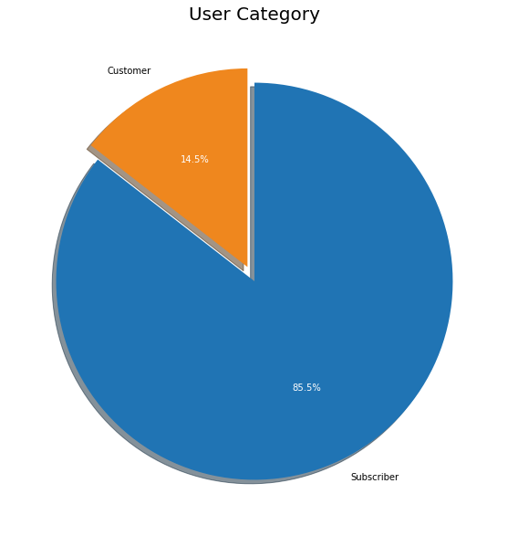

## Monthly Growth Rate

There is steady increase in bike demand up till Jul 2018. Demand reduced slightly in August and September and recovered in October 2018. However, there was a drastic decrease in demand in November and December 2018 and since then, demand has fluctuated monthly.

Changes in number of monthly trips tend to be similar for both user types.

Although, there has been slight increase in demand between April and July 2018, the month-over-month (MoM) growth has been on a decline. It however,hit rock bottom in November, 2018. MoM growth rate has flunctuated since then.

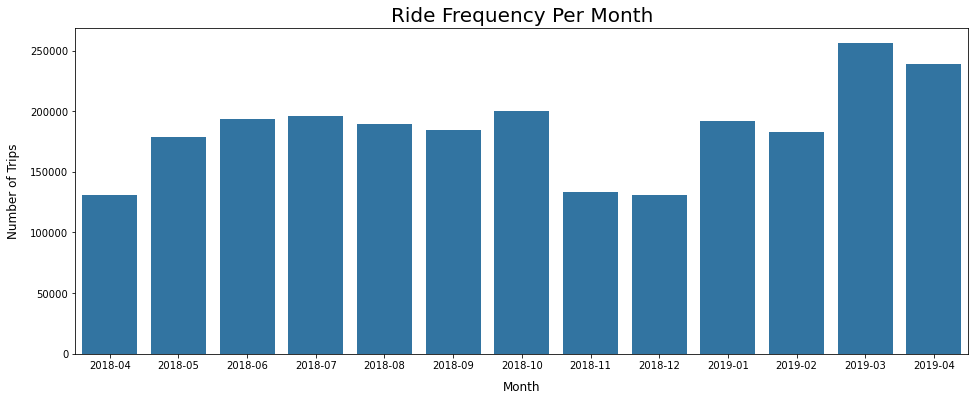

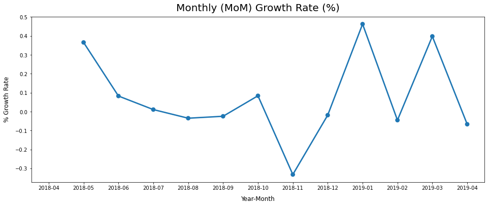

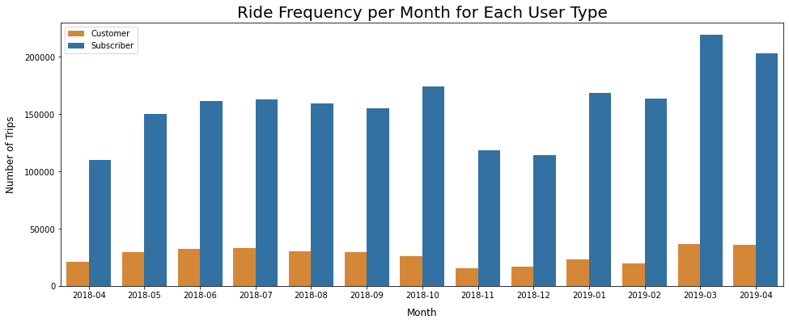

## Distribution of Duration

"Customers" tend to have more duration for their trips, and their distribution also have more spread compared to "Subscribers".

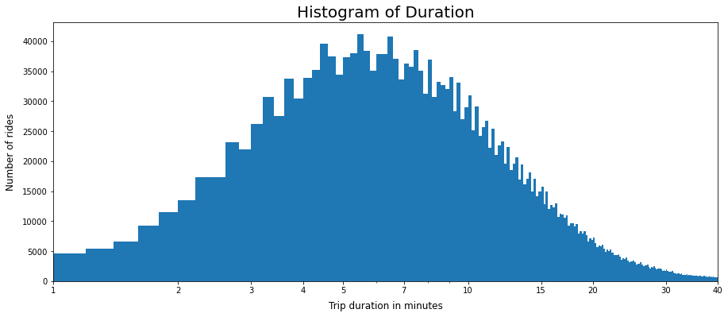

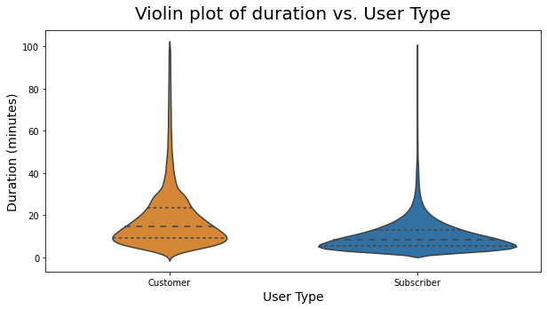

## Daily Ride Frequency

Customers demand follow a similar partern all through the week while Subscribers demand drops significantly on weekends. This indicates that subscribers use bikeshare services to commute to work while customers use the service for various reasons seeing as demand is consistent over the weekend.

Rush hours are between 8-9am in the morning, and 5-6pm in the evening. Although there are less "customers" than "suscribers" between 5am and 9am. there are more "customers from 10am to 4pm.

On average, Trips durations tend to be longer on weekends compared to workdays; Customers take longer trips than suscribers both on weekends and workdays

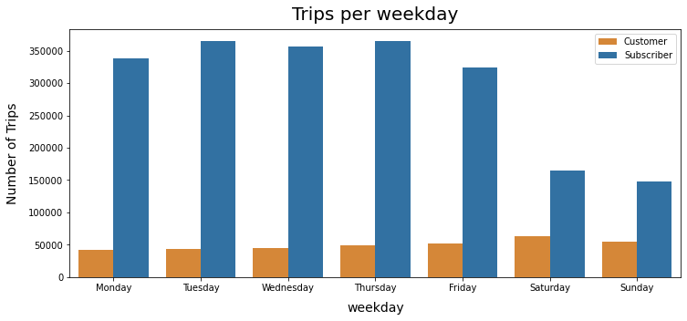

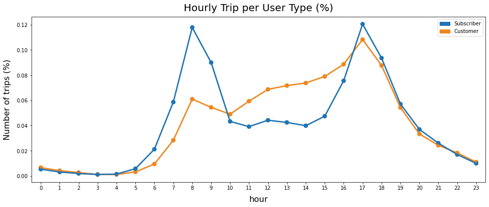

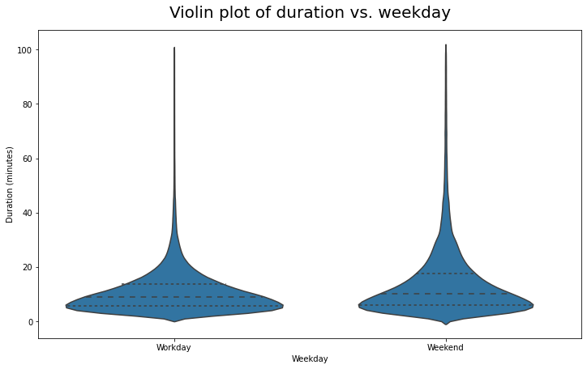

## Most popular Start and End Station

The most popular start and end stations are not entirely the same.

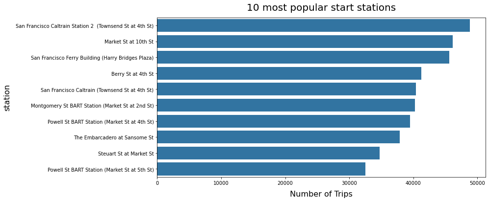

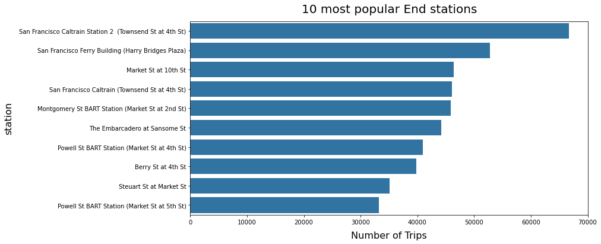